# Lab06NotTeamOne

David Orozco, Arie del Valle, Ryan Tate, Anderson Mun, Ethan Schacht

February 22, 2019

### Team Section

#### Overall Questions

- Main Question: What factors increase the probability of a delayed arrival and what factors decrease the probability of a delayed arrival?
- Vague question: What is the most common factor that may cause a delay?
- These questions are important because no one wants their flight to be delyed and DIA airport managers want to the increase chances of flights arriving on time. Understanding factors that affect the arrival time will help DIA managers decide which policies will be most effective in decreasing delays.

#### Team Graph

```
## # A tibble: 7 x 3
##   ORIGIN count avg_delay
##   <chr>  <int>     <dbl>
## 1 DAL     2410      9.83
## 2 SFO     7265      9.02
## 3 ASE     2132      6.78
## 4 EWR     3252      6.48
## 5 LAX     8515      5.22
## 6 DFW     5401      4.67
## 7 ORD     6585      4.23
```

- Table interpretation: This table groups by airports that fly into Denver and displays their counts and average delays, and must fufill the following criteria: They must have flown at least 2000 flights into DEN in 2017 and they must post an average delay of at least 5 minutes with the exceptions of DFW and ORD (due to these two airports’ massive sample sizes and their average arrival delay over 4 minutes).

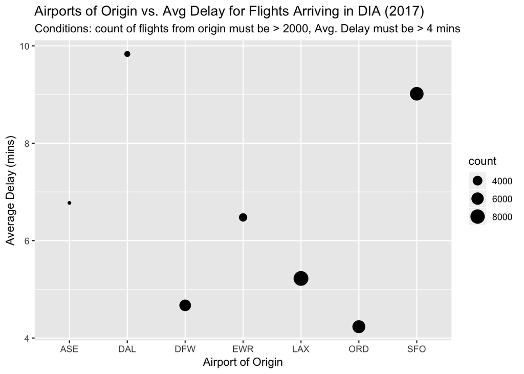

- Graph interpretation: This graph displays airports of origin flying planes into Denver against their high average delays combined with high sample sizes as a confounding variable. We can see that among the airports that fulfill the filtering criteria, DAL flies planes into Denver with the highest average delay at 9.83 minutes. However, SFO and LAX, which fly a much bigger load of over 7000 and over 8000 flights into Denver a year, respectively, post average delays into Denver of 9.01 minutes and 5.22 minutes.

```
## [1] 0.007246377
```

```
##            n
## 1 0.01722313
```

```
##           n
## 1 0.0505536
```

```
##           n
## 1 0.0499814
```

- Probability interpretations: As a total of 138 airports flew into Denver in 2017, we would expect the average probability of an flight coming from any origin given that it’s delayed in Denver to be 0.007, or 1/138. DAL’s probability is 0.017, SFO’s probability is 0.051, and LAX’s probability is 0.050. Although DAL has a lower probability than LAX and SFO (due to lower count coming into Denver), it’s very noteable that it posts the highest average delay, which is bery damaging.

#### Vague Question

- What delay type was the most prominent regarding flights in and out of Denver? Security delays, late aircraft delays, weather delays, NAS delays, or carrier delays?

```
## # A tibble: 1 x 6
##   ALL_LATE SECURITY LATE_AIRCRAFT WEATHER   NAS CARRIER
##      <dbl>    <dbl>         <dbl>   <dbl> <dbl>   <dbl>
## 1    76329      127         40479    3330 41285   38751
```

#### Recommendations

- As data scientists serving for the interests of Denver International Airport, our findings lead us to recommend that we contact many of the airports shown on the graph, especially DAL, LAX, and SFO, regarding their handling of flying planes into Denver as they send the combination of highest average delays with highest flight counts. We also recommend that DIA takes steps to improve numbers on late aircraft, carrier delays, and NAS delays as they are by far the most prominent reasons for overall delays into Denver.

### Individual Section

#### David’s Section

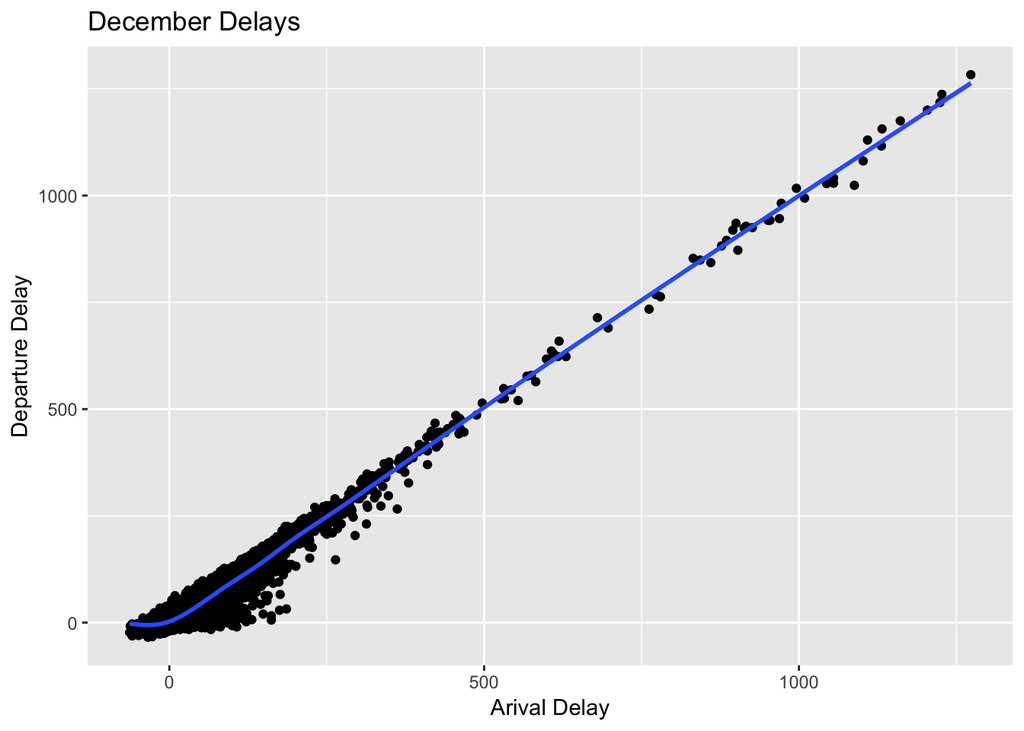

- I used ‘filter’ to seperate all the December flights in 2017.
- There is a strong positive coorelation between between arrival and departure delay.

```
##          n
## 1 29.13331
```

- I used ‘filter’ to seperate all the flights in decemeber that had a delay larger than 15 min. I did the same thing to a tibble of all flights during 23rd-27th of December only.
- There is a 29.1% probabilty that your flight would have been delayed 15min or more in December of 2017 given you flew during the holidays (23rd - 27th of Dec).

#### Arie’s Section

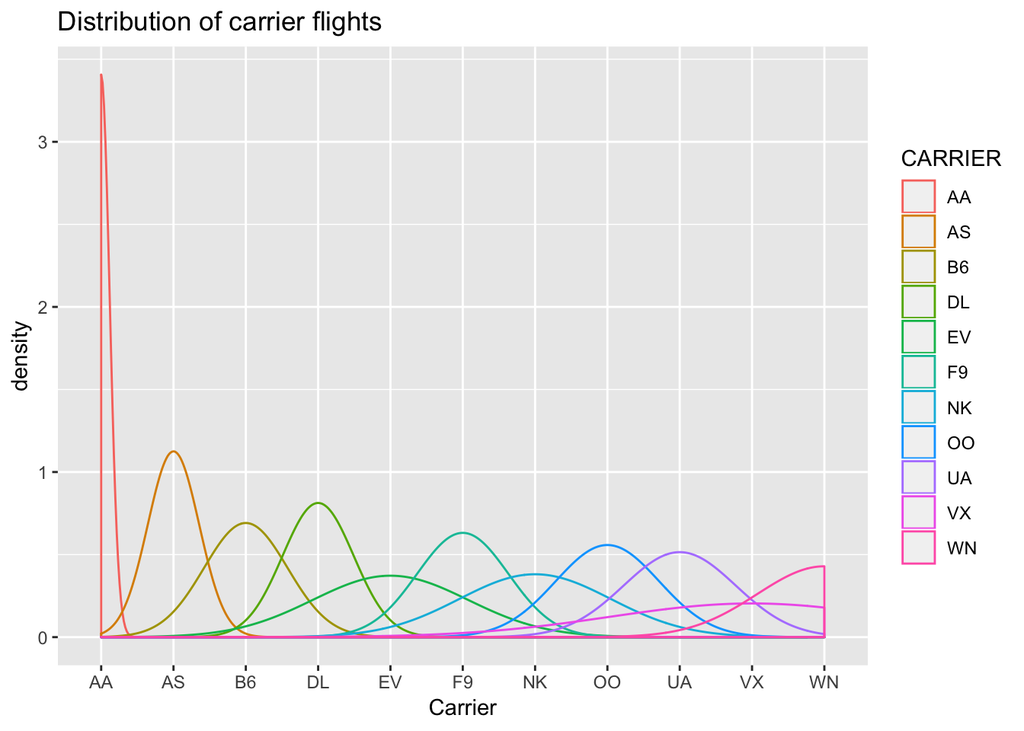

```
##           n
## 1 0.2176264
```

- I graphed the distribution of flights by carrier. From this graph I wanted to see the probability of arrival delays greater than 60 minutes given that the carrier was United.
- I used geom_density to show the distribution of flights by carrier and I also filled it by carrier for a better visualiztion.
- To find the probablity I created the variable delayed_arr and piped the COflights and filterd Denver as the destination and arrival delays greated than 60 minutes. Then I created a second variable, arriv_del_fri_UA, that filters the destination as Denver, United as the carrier, and arrival delays that are greater than 60 mins. Then I calculated the probablity, arriv_del_fri_UA /delayed_arr which was 21.7%.

#### Ethan’s Section

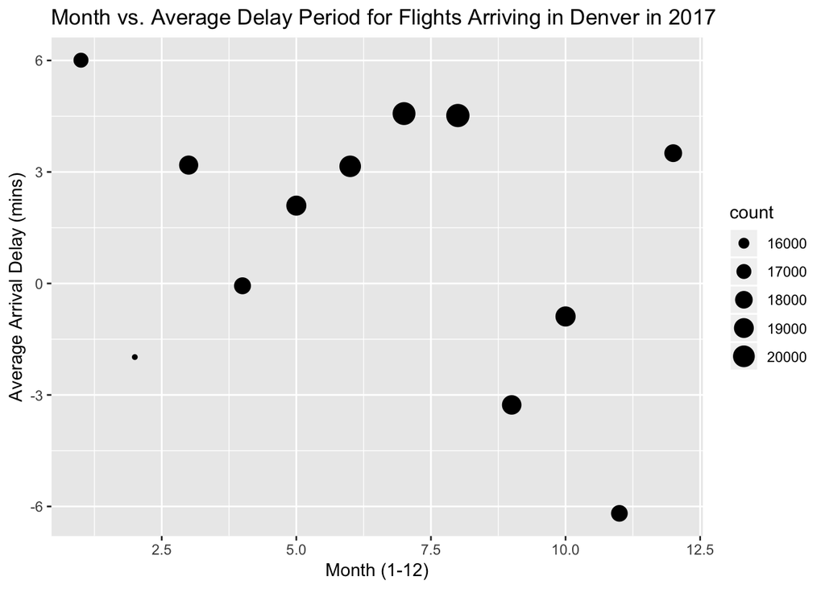

```
##           n
## 1 0.1069436
```

- Findings: The scatterplot uses filtering of destination (DEN), grouping by month, summarizing averages of those months, and size aethetics of flight counts per month to display a visual represnation of the times of year when flights tend to arrive later or earlier. The “slowest” month is January with an average delayed flight time of 6.01 minutes and the “fastest” month is November with an average delayed flight time of -6.19 minutes (6.19 mins early). Conditional probabilities match the graph’s implications, as well. For example, the probability of the month being January given that a flight is delayed (>= 15 mins late) in Denver is 0.107 and the probability of the month being November given that a flight is delayed in Denver is 0.042. Both of these probabilities are well below or above the expected/average probability, or E(x), per month of 0.083 (1/12). There also appears to be a minor correlation between the amount of flights per month, represented by the size of the points, and average arrival delay. For example, 2 of the 3 slowest months (Jul,Aug) contain close to 21,000 flights, representing the busiest months of year, and the fastest month (Nov) contains less that 18,000 flights, representing thethe 3rd least busy month of year. Therefore, we can conclude that both the month and amount of air traffic affects arrival delays in Denver during 2017.

#### Ryan’s Section

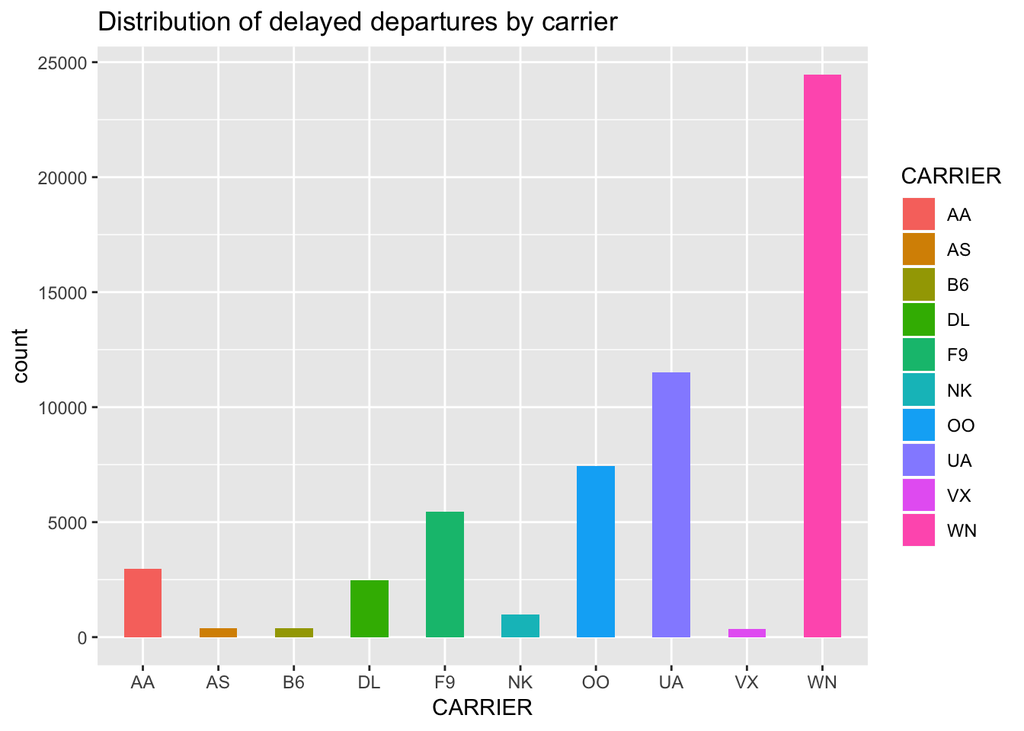

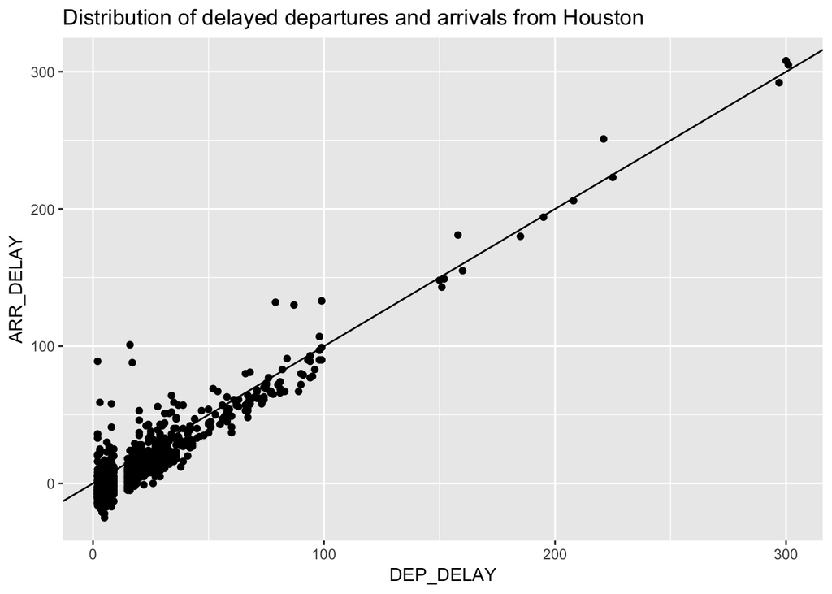

- For my graphs I found the probability of flights to Denver that were delayed given they were from Houston airport, and the probability of flights to Denver that were delayed given they had the carrier WN.
- The probabilities are .3454 and .1787 respectively
- The graph for the Houston probability is a point graph showing the distribution of all arrival delays and departure delays from Houston by the amount of time the delay lasted *The graph for the carrier probability is a histogram of all of the carriers seperated and distinguished by color

#### Anderson’s Section

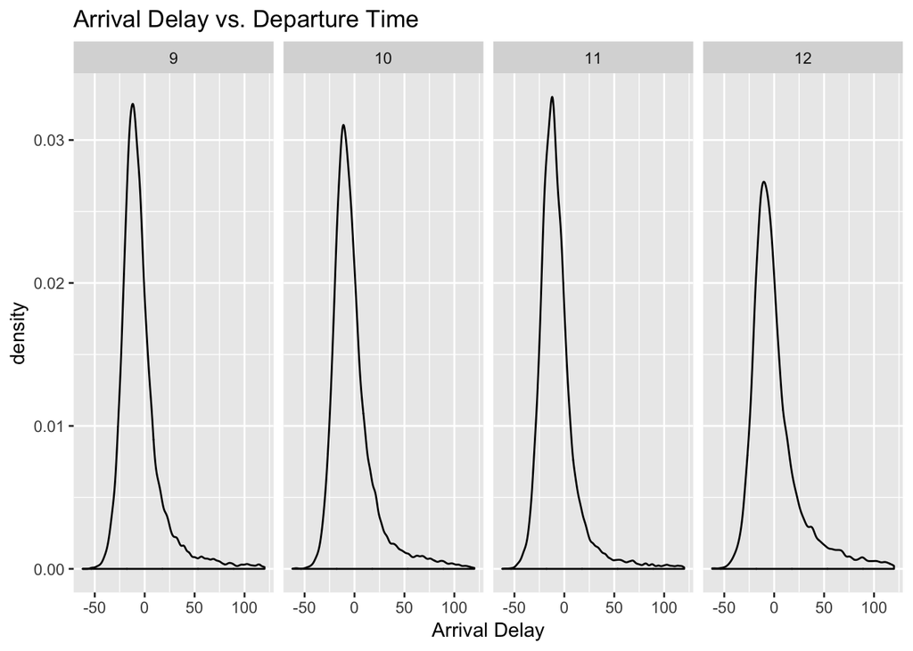

- I used filter to filter out flights that occured from september to december with an arrival delay of two hours after 9:00am.
- There is a large number of people who arrive earlier than later.

```
##            n
## 1 0.07855162
```

- I used filter to find all flights with a departure delay of less than fifteen minutes.
- There is a 7.8% probability of your flight’s departure delay being less than fifteen minutes when you spend over 200 minutes in the air.

### Who did what?

Anderson: Did individual part

Ethan: I completed the inidividual section, created entire graph, probabilities, and explanations/recommendations for team section.

David: I started Github/GitKraken repository, edited R-Markdown format, completed individual section, created a tibble demonstrating the amount of flights in which security, carrier, NAS, or late aircraft delays were a part of a flights overall delay ( greater than 15 min).

Ryan: Did individual part, helped with merge conflicts.

Arie: Did individual part, overall questions and why they are important